# CEE 218X Assignment 2

Brooke Tran

October 11, 2020

# Education Outcomes in Alameda County

```r
library(tidyverse)
library(sf)
library(tigris)
library(leaflet)
library(censusapi)

options(scipen=999)
```

## Equity analysis of educational attainment by race.

```r
Sys.setenv(CENSUS_KEY="c8aa67e4086b4b5ce3a8717f59faa9a28f611dab")

# acs_vars_2018_1yr <-
#   listCensusMetadata(
#     name = "2018/acs/acs1",
#     type = "variables"
#   )
# saveRDS(acs_vars_2018_1yr, "census contents.rds")

acs_vars_2018_1yr = readRDS("census contents.rds")
```

```r
census_race_labels <-
  c(
    "White Alone",
    "Black or African American",
    "American Indian and Alaska Native Alone",
    "Asian Alone",
    "Native Hawaiian and Other Pacific Islander Alone)",
    "Some Other Race Alone",
    "Two or More Races"
  )
```

```r
ed_race <-
  1:7 %>%
  map_dfr(function(x){
    getCensus(
      name = "acs/acs1",
      vintage = 2018,
      region = "county:001",
      regionin = "state:06",
      vars = paste0("group(B15002",LETTERS[x],")")
    ) %>%
      select(!c(GEO_ID,state,NAME) & !ends_with(c("EA","MA","M"))) %>%
      pivot_longer(
        ends_with("E"),
        names_to = "variable",
        values_to = "estimate"
      ) %>%
      left_join(
        acs_vars_2018_1yr %>%
          select(name, label),
        by = c("variable" = "name")
      ) %>%
      select(-variable) %>%
      separate(
        label,
        into = c(NA,NA,"sex","education"),
        sep = "!!"
      ) %>%
      filter(!is.na(education)) %>%
      mutate(race = census_race_labels[x])
  })
```

```r
# Aggregate gender estimates together
ed_race = ed_race %>%
  group_by(education, race) %>%
  summarize(estimate = sum(estimate))
```

```r
theme = theme_bw() +
  theme(
    # Title
    plot.title = element_text(size = 17, family = "Montserrat", face = "bold"),
    plot.subtitle = element_text(size = 11, family = "Montserrat"),
    # Legend
    legend.title = element_blank(),
    legend.position = "bottom",
    legend.text = element_text(family = "Montserrat", size = 9),
    # Caption
    plot.caption = element_text(size = 10, hjust = .5, family = "Montserrat", face = "italic"),
    # Axes
    axis.ticks.x=element_blank(),
    axis.title.x=element_text(family = "Montserrat"),
    axis.text.x=element_text(family = "Montserrat", hjust = 1),
    axis.ticks.y=element_blank(),
    axis.title.y=element_text(family = "Montserrat"),
    axis.text.y=element_text(family = "Montserrat"),
    axis.line = element_line(colour = "black"),
    # Panel
    panel.grid.major = element_blank(),
    panel.grid.minor = element_blank(),
    panel.background = element_blank(),
    panel.border = element_blank(),
    panel.spacing = unit(1, "lines")
  )
```

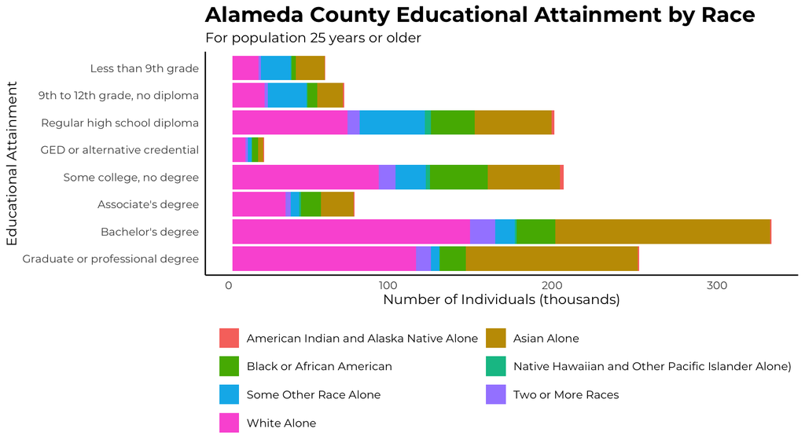

```r
ed_race %>%
  ggplot() +
  geom_bar(
    aes(
      x = education %>% factor(
        levels = rev(c("Less than 9th grade",
                       "9th to 12th grade, no diploma",
                       "Regular high school diploma",
                       "GED or alternative credential",
                       "Some college, no degree",
                       "Associate's degree",
                       "Bachelor's degree",
                       "Graduate or professional degree"))),
      y = estimate/1000,
      fill = race
    ),
    stat = "identity",
    position = "stack"
  ) +
  labs(
    x = "Educational Attainment",
    y = "Number of Individuals (thousands)",
    title = "Alameda County Educational Attainment by Race",
    subtitle = "For population 25 years or older"
  ) +
  theme +
  guides(fill=guide_legend(nrow=4,byrow=TRUE)) +
  coord_flip()
```

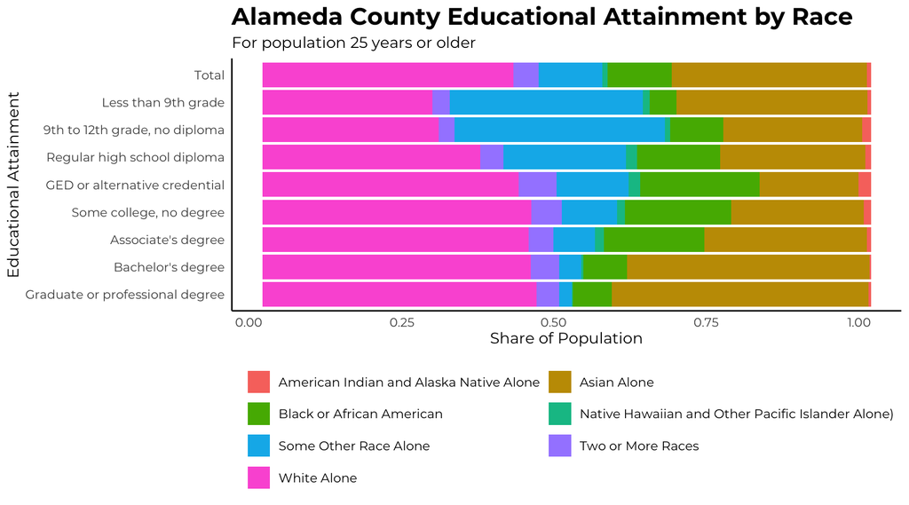

```r
ed_race_total <-
  ed_race %>%
  group_by(race) %>%
  summarize(estimate = sum(estimate)) %>%
  mutate(education = "Total")

ed_race %>%
  group_by(education, race) %>%
  summarize(estimate = sum(estimate)) %>%
  rbind.data.frame(ed_race_total) %>%
  ggplot() +
  geom_bar(
    aes(
      x = education %>% factor(
        levels = rev(c("Total",
                       "Less than 9th grade",
                       "9th to 12th grade, no diploma",
                       "Regular high school diploma",
                       "GED or alternative credential",
                       "Some college, no degree",
                       "Associate's degree",
                       "Bachelor's degree",
                       "Graduate or professional degree"))),
      y = estimate/1000,
      fill = race
    ),
    stat = "identity",
    position = "fill"
  ) +
  labs(
    x = "Educational Attainment",
    y = "Share of Population",
    title = "Alameda County Educational Attainment by Race",
    subtitle = "For population 25 years or older"
  ) +
  theme +
  guides(fill=guide_legend(nrow=4,byrow=TRUE)) +
  coord_flip()
```

```r
# Population breakdown:
# % Non-white
((sum(ed_race_total$estimate[1:6])/sum(ed_race_total$estimate))*100) %>% round()
```

```
## [1] 59
```

```r
# % Black
((sum(ed_race_total$estimate[3])/sum(ed_race_total$estimate))*100) %>% round()
```

```
## [1] 11
```

```r
# % Asian
((sum(ed_race_total$estimate[2])/sum(ed_race_total$estimate))*100) %>% round()
```

```
## [1] 32
```

```r
# % non-white with at least a Bachelor's
((ed_race %>%
  filter(education %in% c("Bachelor's degree", "Graduate or professional degree")) %>%
  filter(race != "White Alone") %>%
  pull(estimate) %>%
  sum()) /
  (ed_race %>%
    filter(education %in% c("Bachelor's degree", "Graduate or professional degree")) %>%
    pull(estimate) %>%
    sum()) * 100) %>%
  round()
```

```
## [1] 55
```

```r
# % Black with at least a Bachelor's
((ed_race %>%
  filter(education %in% c("Bachelor's degree", "Graduate or professional degree")) %>%
  filter(race == "Black or African American") %>%
  pull(estimate) %>%
  sum()) /
  (ed_race %>%
    filter(education %in% c("Bachelor's degree", "Graduate or professional degree")) %>%
    pull(estimate) %>%
    sum()) * 100) %>%
  round()
```

```
## [1] 7
```

```r
# % Asian with at least a Bachelor's
((ed_race %>%
  filter(education %in% c("Bachelor's degree", "Graduate or professional degree")) %>%
  filter(race == "Asian Alone") %>%
  pull(estimate) %>%
  sum()) /
  (ed_race %>%
    filter(education %in% c("Bachelor's degree", "Graduate or professional degree")) %>%
    pull(estimate) %>%
    sum()) * 100) %>%
  round()
```

```
## [1] 41
```

```r
(55-59)/59
```

```
## [1] -0.06779661
```

```r
(7-11)/11
```

```
## [1] -0.3636364
```

```r
(41-32)/32
```

```
## [1] 0.28125
```

Is there disproportionate education attainment by race in the County?

## Estimate of the number and percentage of K-12 students who have no internet access at home

```r
library(tidycensus)

census_api_key("c8aa67e4086b4b5ce3a8717f59faa9a28f611dab")

pums_vars_2018 <-
  pums_variables %>%
  filter(year == 2018, survey == "acs5")

pums_vars_2018_distinct_hh <-
  pums_vars_2018 %>%
  distinct(var_code, var_label, data_type, level) %>%
  filter(level == "housing")
```

```r
# var_code: ACCESS, FPARC, HUPAC, NOC, R18, NRC
# ca_pums <- get_pums(
#   variables = c(
#     "PUMA",
#     "NP",
#     "ACCESS",
#     "FPARC",
#     "HUPAC",
#     "NOC",
#     "R18",
#     "NRC"
#   ),
#   state = "CA",
#   year = 2018,
#   survey = "acs5",
#   recode = T
# )
#
# saveRDS(ca_pums, "ca_pums.rds")

ca_pums = readRDS("ca_pums.rds")
```

```r
ca_counties <- counties("CA", cb = T, progress_bar = F)

bay_county_names <-
  c(
    "Alameda",
    "Contra Costa",
    "Marin",
    "Napa",
    "San Francisco",
    "San Mateo",
    "Santa Clara",
    "Solano",
    "Sonoma"
  )

bay_counties <-
  ca_counties %>%
  filter(NAME %in% bay_county_names)

alameda_county <-
  ca_counties %>%
  filter(NAME %in% "Alameda")
```

```r
ca_pumas <-
  pumas("CA", cb = T, progress_bar = F)

# Get values for Alameda only
alameda_pumas <-
  ca_pumas %>%
  st_centroid() %>%
  .[alameda_county, ] %>%
  st_set_geometry(NULL) %>%
  left_join(ca_pumas %>% select(GEOID10)) %>%
  st_as_sf()

alameda_pums <-
  ca_pums %>%
  filter(PUMA %in% alameda_pumas$PUMACE10)
```

```r
# Filter for households with someone under 18
# Remove duplicate households
alameda_pums_clean = alameda_pums %>%
  filter(R18_label == "1 or more persons under 18 in household") %>%
  filter(!duplicated(SERIALNO)) %>%
  filter(NRC >= 0) # Remove negative values for number of children variable?

# NRC = total number of children in house (number related children)
# Create column indicating number of children in data without internet
alameda_pums_clean = alameda_pums_clean %>%
  mutate(num_no_internet_weighted = ifelse(ACCESS == 3, NRC*WGTP, 0),
         num_children_weighted = NRC*WGTP)

# Compute number of children with no internet access
sum(alameda_pums_clean$num_no_internet_weighted) # 18415
```

```
## [1] 18415
```

```r
# Percentage of chldren with no internet access
sum(alameda_pums_clean$num_no_internet_weighted)/sum(alameda_pums_clean$num_children_weighted)
```

```
## [1] 0.0547904
```

```r
# 5.5%
```

In Alameda County, there are an estimated 18,415 individuals under the age of 18 that do not have Internet access. Said differently, out of all young students under 18 in Alameda County, 5.5% of them do not have Internet. This estimate was obtained by computing the number of children within a household (NRC variable in PUMS data) without internet access, and applying the corresponding weight to each household.

Given the necessity for remote learning due to school closures during the pandemic, these results are especially important in understanding how many students do not have the resources to learn from home. To address these challenges, local governments and school districts could utilize this data to guide the allocation of resources to meet the needs of these students.

## Mapping Internet access in the Bay Area

```r
bay_pumas <-
  ca_pumas %>%
  st_centroid() %>%
  .[bay_counties, ] %>%
  st_set_geometry(NULL) %>%
  left_join(ca_pumas %>% select(GEOID10)) %>%
  st_as_sf()

bay_pums <-
  ca_pums %>%
  filter(PUMA %in% bay_pumas$PUMACE10)
```

```r
bay_pums_internet <-
  bay_pums %>%
  filter(R18_label == "1 or more persons under 18 in household") %>%
  filter(!duplicated(SERIALNO)) %>%
  filter(NRC >= 0) %>% # Remove negative values for number of children variable?

  mutate(
    num_no_internet_weighted = ifelse(
      ACCESS == 3, NRC*WGTP, 0),
    num_children_weighted = NRC*WGTP
  ) %>%

  group_by(PUMA) %>%
  summarize(
    pct_children_without_internet =
      sum(num_no_internet_weighted, na.rm =T)/sum(num_children_weighted, na.rm = T)*100
  ) %>%
  left_join(
    bay_pumas %>%
      select(PUMACE10),
    by = c("PUMA" = "PUMACE10")
  ) %>%
  st_as_sf()

pums_pal <- colorNumeric(
  palette = "Oranges",
  domain = bay_pums_internet$pct_children_without_internet
)

leaflet() %>%
  addProviderTiles(providers$CartoDB.Positron) %>%
  addPolygons(
    data = bay_pums_internet,
    fillColor = ~pums_pal(pct_children_without_internet),
    color = "white",
    opacity = 0.5,
    fillOpacity = 0.7,
    weight = 1,
    label = ~paste0(
      round(pct_children_without_internet),
      "% children without access to Internet"
    ),
    highlightOptions = highlightOptions(
      weight = 2,
      opacity = 1
    )
  ) %>%
  addLegend(
    data = bay_pums_internet,
    pal = pums_pal,
    values = ~pct_children_without_internet,
    title = "% Children without<br>Internet Access"
  )
```

[interactive chart not shown]

From the map, we can identify areas with high concentrations of children lacking Internet access. We can see that there is a particular need in the East Bay, specifically within west Oakland. There is also a high percentage of these children in the region encompassing East Palo Alto and parts of San Jose.

# Migration analysis by educational attainment

```r
# acs_vars_2019_1yr <-
#   listCensusMetadata(
#     name = "2019/acs/acs1",
#     type = "variables"
#   )

# saveRDS(acs_vars_2018_1yr, "census contents 2019.rds")

acs_vars_2019_1yr = readRDS("census contents 2019.rds")
```

```r
# B07009: GEOGRAPHICAL MOBILITY IN THE PAST YEAR BY EDUCATIONAL ATTAINMENT FOR CURRENT RESIDENCE IN THE UNITED STATES

alm_mobility_current_19 <-
  getCensus(
    name = "acs/acs1",
    vintage = 2019,
    region = "county:001",
    regionin = "state:06",
    vars = c("group(B07009)")
  ) %>%
  select(!c(GEO_ID,state,NAME) & !ends_with(c("EA","MA","M"))) %>%
  pivot_longer(
    ends_with("E"),
    names_to = "variable",
    values_to = "estimate"
  ) %>%
  left_join(
    acs_vars_2019_1yr %>%
      select(name, label),
    by = c("variable" = "name")
  ) %>%
  select(-variable) %>%
  separate(
    label,
    into = c(NA,NA,"mobility","education"),
    sep = "!!"
  ) %>%
  mutate(
    mobility = ifelse(
      mobility %in% c("Same house 1 year ago:", "Moved within same county:"),
      "Here since last year",
      "Inflow"
    )
  ) %>%
  filter(!is.na(education)) %>%
  group_by(mobility, education) %>%
  summarize(estimate = sum(estimate))
```

```r
# B07409: GEOGRAPHICAL MOBILITY IN THE PAST YEAR BY EDUCATIONAL ATTAINMENT FOR RESIDENCE 1 YEAR AGO IN THE UNITED STATES
alm_mobility_lastyear_19 <-
  getCensus(
    name = "acs/acs1",
    vintage = 2019,
    region = "county:001",
    regionin = "state:06",
    vars = c("group(B07409)")
  ) %>%
  select(!c(GEO_ID,state,NAME) & !ends_with(c("EA","MA","M"))) %>%
  pivot_longer(
    ends_with("E"),
    names_to = "variable",
    values_to = "estimate"
  ) %>%
  left_join(
    acs_vars_2019_1yr %>%
      select(name, label),
    by = c("variable" = "name")
  ) %>%
  select(-variable) %>%
  separate(
    label,
    into = c(NA,NA,"mobility","education"),
    sep = "!!"
  ) %>%
  mutate(
    mobility = ifelse(
      mobility %in% c("Same house:", "Moved within same county:"),
      "Here since last year",
      "Outflow"
    )
  ) %>%
  filter(!is.na(education)) %>%
  group_by(mobility, education) %>%
  summarize(estimate = sum(estimate))
```

```r
alm_mobility_current_18 <-
  getCensus(
    name = "acs/acs1",
    vintage = 2018,
    region = "county:001",
    regionin = "state:06",
    vars = c("group(B07009)")
  ) %>%
  select(!c(GEO_ID,state,NAME) & !ends_with(c("EA","MA","M"))) %>%
  pivot_longer(
    ends_with("E"),
    names_to = "variable",
    values_to = "estimate"
  ) %>%
  left_join(
    acs_vars_2019_1yr %>%
      select(name, label),
    by = c("variable" = "name")
  ) %>%
  select(-variable) %>%
  separate(
    label,
    into = c(NA,NA,"mobility","education"),
    sep = "!!"
  ) %>%
  mutate(
    mobility = "Here last year"
  ) %>%
  filter(!is.na(education)) %>%
  group_by(mobility, education) %>%
  summarize(estimate = sum(estimate))
```

```r
alm_flows_19 <-
  rbind.data.frame(
    alm_mobility_current_18,
    alm_mobility_lastyear_19 %>%
      filter(mobility == "Outflow"),
    alm_mobility_current_19 %>%
      filter(mobility == "Inflow"),
    alm_mobility_current_19 %>%
      group_by(education) %>%
      summarize(estimate = sum(estimate)) %>%
      mutate(mobility = "Here this year")
  ) %>%
  pivot_wider(
    names_from = mobility,
    values_from = estimate
  ) %>%
  mutate(
    `External net` = Inflow - Outflow,
    `Internal net` = `Here this year` - `Here last year` - `External net`,
  ) %>%
  select(
    `Educational Attainment` = education,
    `Internal net`,
    `External net`,
    `Here last year`,
    `Here this year`,
    Outflow,
    Inflow
  )

alm_flows_19
```

| Educational Attainment | Internal net | External net | Here last year | Here this year | Outflow | Inflow |
| --- | --- | --- | --- | --- | --- | --- |
| Bachelor's degree | 18271 | 6034 | 326386 | 350691 | 344657 | 350691 |
| Graduate or professional degree | 6148 | 1515 | 246460 | 254123 | 252608 | 254123 |
| High school graduate (includes equivalency) | -7992 | -15 | 214368 | 206361 | 206376 | 206361 |
| Less than high school graduate | -1335 | 1174 | 124223 | 124062 | 122888 | 124062 |
| Some college or associate's degree | -8890 | -6028 | 274788 | 259870 | 265898 | 259870 |

To analyze the educational mobility of Alameda residents, we can focus on the internal net flow, which reflects movement between educational attainment tiers among Alameda residents. It also accounts for births and deaths, along with those who left the country, however this likely only comprises a small amount of the total internal net flow. We can ignore the external net flow, which reflects the in- and outmigration of residents to the geographic area.

Based on the estimates for internal net flow, there is strong evidence for educational mobility in Alameda. There was positive internal net flow for the highest levels of education: bachelor’s degree and above, while there were significant negative internal flows for the lowest educational levels. This indicates that in the past year, Alameda residents on average moved up to a higher education tier (since we know individuals cannot move “backwards” in their education). Overall, we saw the highest net increase in the number of bachelor’s degrees obtained by Alameda residents. The highest net decrease occurred in the “some college or an associate’s degree” tier, meaning this group saw the largest net flow of students obtaining higher levels of education.